# Capstone (2)

### Removing Multicollinearity

```python
from statsmodels.stats.outliers_influence import variance_inflation_factor

vif = pd.DataFrame()

df_numeric = DF_num.drop('Salary',axis=1)

vif["Features"] = df_numeric.columns

vif['VIF']=[variance_inflation_factor(df_numeric.values, i) for i in range(df_numeric.shape[1])]

X_filtered=vif[vif['VIF']<10]['Features']
```

```python
# iterative
```

```python
X_num=df_numeric.loc[:,X_filtered]
```

```python
X=pd.concat([X_num,DF_cat],axis=1)
X=sm.add_constant(X)

Y=(df.Salary)
X.shape
```

```
(3998, 60)
```

```python
X_train_slr, X_test_slr, y_train_slr, y_test_slr = train_test_split(X, np.log(Y),random_state=0, test_size = 0.3)

SLR_model3 = sm.OLS(y_train_slr, X_train_slr).fit()
# print the summary output
SLR_model3.summary()
```

OLS Regression Results

| Dep. Variable: | Salary | R-squared: | 0.161 |
| --- | --- | --- | --- |
| Model: | OLS | Adj. R-squared: | 0.143 |
| Method: | Least Squares | F-statistic: | 8.915 |
| Date: | Wed, 26 Jan 2022 | Prob (F-statistic): | 1.94e-68 |
| Time: | 19:10:22 | Log-Likelihood: | -1964.3 |
| No. Observations: | 2798 | AIC: | 4049. |
| Df Residuals: | 2738 | BIC: | 4405. |
| Df Model: | 59 |  |  |
| Covariance Type: | nonrobust |  |  |

|  | coef | std err | t | P>\|t\| | [0.025 | 0.975] |
| --- | --- | --- | --- | --- | --- | --- |
| const | 12.4607 | 0.106 | 117.155 | 0.000 | 12.252 | 12.669 |
| Domain | 0.1317 | 0.027 | 4.826 | 0.000 | 0.078 | 0.185 |
| ComputerProgramming | 0.0004 | 6.37e-05 | 6.033 | 0.000 | 0.000 | 0.001 |
| ElectronicsAndSemicon | -0.0001 | 0.000 | -1.070 | 0.285 | -0.000 | 0.000 |
| ComputerScience | -0.0005 | 5.82e-05 | -9.009 | 0.000 | -0.001 | -0.000 |
| MechanicalEngg | 5.106e-05 | 0.000 | 0.214 | 0.831 | -0.000 | 0.001 |
| ElectricalEngg | -0.0003 | 0.000 | -2.246 | 0.025 | -0.001 | -4.36e-05 |
| TelecomEngg | -0.0001 | 0.000 | -0.936 | 0.350 | -0.000 | 0.000 |
| CivilEngg | 0.0005 | 0.001 | 0.923 | 0.356 | -0.001 | 0.002 |
| conscientiousness | -0.0482 | 0.011 | -4.234 | 0.000 | -0.071 | -0.026 |
| agreeableness | 0.0608 | 0.014 | 4.450 | 0.000 | 0.034 | 0.088 |
| extraversion | -0.0001 | 0.012 | -0.009 | 0.993 | -0.023 | 0.023 |
| nueroticism | -0.0409 | 0.010 | -4.002 | 0.000 | -0.061 | -0.021 |
| openess_to_experience | -0.0215 | 0.012 | -1.785 | 0.074 | -0.045 | 0.002 |
| Gender | 0.0303 | 0.023 | 1.327 | 0.185 | -0.014 | 0.075 |
| CollegeTier | 0.3948 | 0.044 | 8.974 | 0.000 | 0.309 | 0.481 |
| Gap_in_Education | -0.0233 | 0.023 | -1.010 | 0.313 | -0.068 | 0.022 |
| 12board_IB | -0.4569 | 0.499 | -0.916 | 0.360 | -1.435 | 0.521 |
| 12board_ICSE | 0.0946 | 0.048 | 1.990 | 0.047 | 0.001 | 0.188 |
| 12board_STATE BOARD | -0.0828 | 0.024 | -3.413 | 0.001 | -0.130 | -0.035 |
| Degree_M.Sc. (Tech.) | 0.1938 | 0.358 | 0.542 | 0.588 | -0.508 | 0.895 |
| Degree_M.Tech./M.E. | -0.0047 | 0.079 | -0.060 | 0.952 | -0.160 | 0.150 |
| Degree_MCA | -0.1871 | 0.045 | -4.171 | 0.000 | -0.275 | -0.099 |
| Specialization_biotechnology | -0.0016 | 0.180 | -0.009 | 0.993 | -0.355 | 0.352 |
| Specialization_civil engineering | -0.0805 | 0.267 | -0.302 | 0.763 | -0.603 | 0.442 |
| Specialization_computer science and engineering | -0.0733 | 0.097 | -0.755 | 0.450 | -0.264 | 0.117 |
| Specialization_electrical engineering | -0.0248 | 0.118 | -0.209 | 0.834 | -0.257 | 0.207 |
| Specialization_electronics and communication engineering | -2.279e-05 | 0.094 | -0.000 | 1.000 | -0.184 | 0.184 |
| Specialization_electronics and electrical engineering | -0.0502 | 0.105 | -0.480 | 0.631 | -0.255 | 0.155 |
| Specialization_electronics and instrumentation engineering | 0.0755 | 0.125 | 0.604 | 0.546 | -0.169 | 0.320 |
| Specialization_electronics and telecommunication engineering | 0.0547 | 0.108 | 0.506 | 0.613 | -0.157 | 0.267 |
| Specialization_industrial and production engineering | 0.0769 | 0.226 | 0.341 | 0.733 | -0.365 | 0.519 |
| Specialization_information technology | -0.0352 | 0.098 | -0.359 | 0.719 | -0.227 | 0.157 |
| Specialization_instrumentation and control engineering | 0.1188 | 0.165 | 0.721 | 0.471 | -0.204 | 0.442 |
| Specialization_mechanical engineering | -0.0761 | 0.116 | -0.656 | 0.512 | -0.304 | 0.151 |
| CollegeState_Assam | 0.6186 | 0.500 | 1.236 | 0.216 | -0.363 | 1.600 |
| CollegeState_Bihar | -0.4431 | 0.173 | -2.568 | 0.010 | -0.782 | -0.105 |
| CollegeState_Chhattisgarh | -0.1536 | 0.124 | -1.234 | 0.217 | -0.398 | 0.090 |
| CollegeState_Delhi | -0.1924 | 0.072 | -2.680 | 0.007 | -0.333 | -0.052 |
| CollegeState_Goa | 0.7069 | 0.506 | 1.396 | 0.163 | -0.286 | 1.700 |
| CollegeState_Gujarat | -0.2189 | 0.137 | -1.597 | 0.110 | -0.488 | 0.050 |
| CollegeState_Haryana | -0.1076 | 0.063 | -1.706 | 0.088 | -0.231 | 0.016 |
| CollegeState_Himachal Pradesh | -0.1112 | 0.152 | -0.733 | 0.464 | -0.409 | 0.186 |
| CollegeState_Jammu and Kashmir | -0.1136 | 0.227 | -0.501 | 0.617 | -0.558 | 0.331 |
| CollegeState_Jharkhand | 0.2576 | 0.121 | 2.127 | 0.033 | 0.020 | 0.495 |
| CollegeState_Karnataka | 0.0591 | 0.051 | 1.163 | 0.245 | -0.041 | 0.159 |
| CollegeState_Kerala | -0.2904 | 0.114 | -2.556 | 0.011 | -0.513 | -0.068 |
| CollegeState_Madhya Pradesh | -0.0365 | 0.061 | -0.596 | 0.551 | -0.157 | 0.084 |
| CollegeState_Maharashtra | -0.1179 | 0.057 | -2.085 | 0.037 | -0.229 | -0.007 |
| CollegeState_Meghalaya | -0.2872 | 0.497 | -0.578 | 0.563 | -1.261 | 0.687 |
| CollegeState_Orissa | -0.0179 | 0.062 | -0.286 | 0.775 | -0.140 | 0.105 |
| CollegeState_Punjab | -0.1280 | 0.064 | -1.997 | 0.046 | -0.254 | -0.002 |
| CollegeState_Rajasthan | -0.1394 | 0.061 | -2.271 | 0.023 | -0.260 | -0.019 |
| CollegeState_Sikkim | 0.1022 | 0.353 | 0.290 | 0.772 | -0.590 | 0.795 |
| CollegeState_Tamil Nadu | -0.1164 | 0.050 | -2.309 | 0.021 | -0.215 | -0.018 |
| CollegeState_Telangana | -0.0508 | 0.052 | -0.968 | 0.333 | -0.154 | 0.052 |
| CollegeState_Union Territory | -0.4800 | 0.251 | -1.913 | 0.056 | -0.972 | 0.012 |
| CollegeState_Uttar Pradesh | -0.1070 | 0.048 | -2.206 | 0.027 | -0.202 | -0.012 |
| CollegeState_Uttarakhand | -0.1059 | 0.071 | -1.496 | 0.135 | -0.245 | 0.033 |
| CollegeState_West Bengal | -0.1251 | 0.060 | -2.086 | 0.037 | -0.243 | -0.008 |

| Omnibus: | 93.390 | Durbin-Watson: | 2.084 |
| --- | --- | --- | --- |
| Prob(Omnibus): | 0.000 | Jarque-Bera (JB): | 184.179 |
| Skew: | -0.232 | Prob(JB): | 1.01e-40 |
| Kurtosis: | 4.168 | Cond. No. | 2.32e+04 |

Notes:  
[1] Standard Errors assume that the covariance matrix of the errors is correctly specified.  
[2] The condition number is large, 2.32e+04. This might indicate that there are  
strong multicollinearity or other numerical problems.

```python
y_pred_train=SLR_model3.predict(X_train_slr)

y_pred_test=SLR_model3.predict(X_test_slr)
```

```python
SLR_model3_Rsq=(SLR_model3.rsquared)

SLR_model3_Rsq_adj=SLR_model3.rsquared_adj

SLR_model3_train_rmse=np.sqrt(mean_squared_error(np.exp(y_train_slr),np.exp(y_pred_train)))

SLR_model3_test_rmse=np.sqrt(mean_squared_error(np.exp(y_test_slr),np.exp(y_pred_test)))
```

```python
print('Model R2 is:',(SLR_model3.rsquared))
print()
print('Model Adjusted R2 is:',SLR_model3.rsquared_adj)
print()
print('RMSE on train data with base model is:', SLR_model3_train_rmse)
print()
print('RMSE on test data with base model is:',SLR_model3_test_rmse)
```

```
Model R2 is: 0.16114533667550857

Model Adjusted R2 is: 0.1430692135432423

RMSE on train data with base model is: 175997.37345943684

RMSE on test data with base model is: 265896.68139044236
```

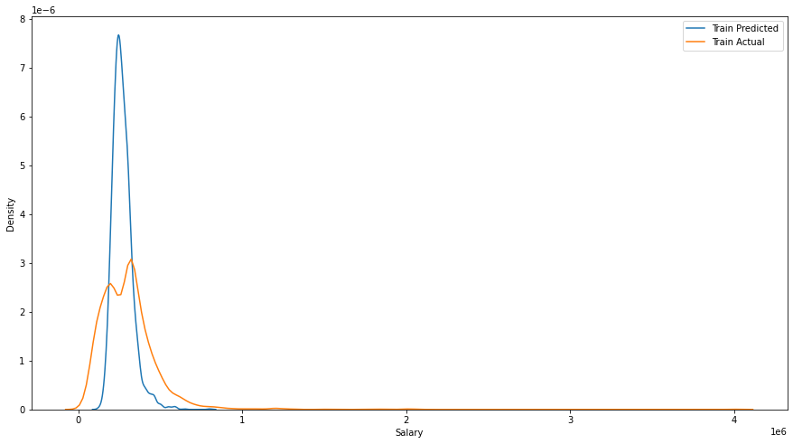

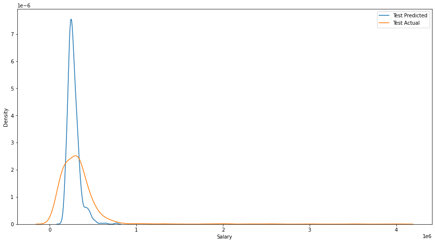

```python
fig,axes=plt.subplots(1,1)
sns.distplot(np.exp(y_pred_train),label='Train Predicted',hist=False)
sns.distplot(np.exp(y_train_slr),label='Train Actual',hist=False)
plt.legend()

fig,axes=plt.subplots(1,1)
sns.distplot(np.exp(y_pred_test),label='Test Predicted',hist=False)
sns.distplot(np.exp(y_test_slr),label='Test Actual',hist=False)
plt.legend()
```

**Creating a DataFrame to compare all the OLS models**

```python
OLS_models=pd.DataFrame({'Model Name':['Base Model1','Base Model2','SLR model1','SLR_model2','SLR_model3'],
                 'Rsquared':[SLR_BM1_Rsq,SLR_BM2_Rsq,SLR_model1_Rsq,SLR_model2_Rsq,SLR_model3_Rsq],
             'Adjusted_Rsquare':[SLR_BM1_Rsq_adj,SLR_BM2_Rsq_adj,SLR_model1_Rsq_adj,SLR_model2_Rsq_adj,SLR_model3_Rsq_adj],
             'Train RMSE':[SLR_BM1_train_RMSE,SLR_BM2_train_RMSE,SLR_model1_train_rmse,SLR_model2_train_rmse,SLR_model3_train_rmse],
             'Test RMSE':[SLR_BM1_test_RMSE,SLR_BM2_test_RMSE,SLR_model_test_rmse,SLR_model2_test_rmse,SLR_model3_test_rmse]})
```

```python
OLS_models['Train_Test_diff']=abs(OLS_models['Train RMSE']-OLS_models['Test RMSE'])
```

### OLS Models deployed till now

```python
OLS_models.sort_values('Train_Test_diff')
```

|  | Model Name | Rsquared | Adjusted_Rsquare | Train RMSE | Test RMSE | Train_Test_diff |
| --- | --- | --- | --- | --- | --- | --- |
| 1 | Base Model2 | 0.17952 | 0.17242 | 195826.47216 | 189891.02512 | 5935.44704 |
| 0 | Base Model1 | 0.17952 | 0.17242 | 216191.20227 | 204402.32514 | 11788.87713 |
| 4 | SLR_model3 | 0.16115 | 0.14307 | 175997.37346 | 265896.68139 | 89899.30793 |
| 2 | SLR model1 | 0.18814 | 0.16852 | 166033.93293 | 258676.24593 | 92642.31300 |
| 3 | SLR_model2 | 0.26644 | 0.24871 | 169303.36229 | 263507.38752 | 94204.02524 |

## Linear Regression :

### Assumptions After Model Building

### 1.Data Is Linear

**Ho : Data is Linear**

**H1: Data is not Linear**

```python
import statsmodels.api as sm

mod3_p=sm.stats.diagnostic.linear_rainbow(SLR_model3)[1]

if mod3_p>0.05:
    print('Data is Linear')
else:
    print('Data is not linear')
```

```
Data is Linear
```

**Graphical representation of the above Statistical Test**

```python
import matplotlib.pyplot as plt
import seaborn as sns
plt.rcParams['figure.figsize']=15,8
```

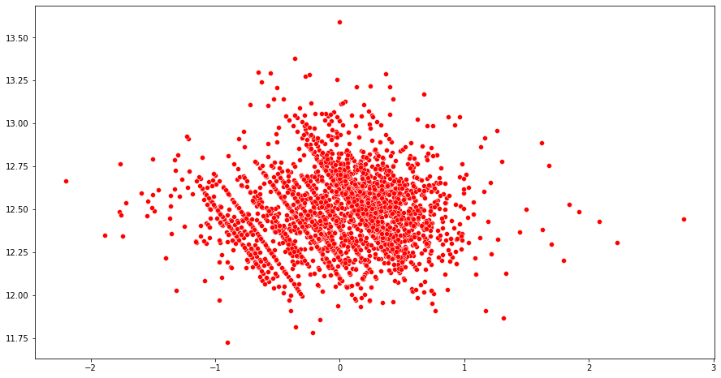

```python
sns.scatterplot(SLR_model3.resid,y_pred_train,color='red')
# plt.title('Linearity of Data',loc='center',fondict={'fontsize': 20})
```

**Interpretation:Since there is randomness in the plot of fitted values VS residuals we can say that the data is linear**

### 2.Normality of Residuals

**Since data is less than 5000rows so we apply Shapiro Wilk test**

**Ho: Residuals are normal**

**H1:Residuals are not normal**

```python
mod3_p=stats.shapiro(SLR_model3.resid)[1]

if mod3_p >0.05:
    print('residuals are Normal')
else:
    print('Residuals are not normal')
```

```
Residuals are not normal
```

**Graphical Representation of the above statistical test**

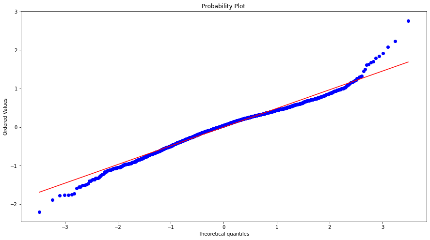

```python
from scipy.stats import probplot
probplot(SLR_model3.resid,plot=plt)
plt.show()
```

**Interpretation:From the probplot as well as the statistical test we can see that the residuals are not normal**

### 3.Autocorrelation of Errors

```python
from statsmodels.stats.stattools import durbin_watson

Statistic=durbin_watson(SLR_model3.resid)

if (Statistic>1.5 ) and (Statistic<2.5):
    print('There is no autocorrelation of errors')
else:
    print('There is autocorrelation of errors')
```

```
There is no autocorrelation of errors
```

### 4.Heteroskedasticity

```python
from statsmodels.stats.api import het_breuschpagan

het_p=het_breuschpagan(SLR_model3.resid,X_train_slr)[1]

if het_p>0.05:
    print('Residuals are Homoskedastic')
else:
    print('Residuals are Heteroskedastic')
```

```
Residuals are Heteroskedastic
```

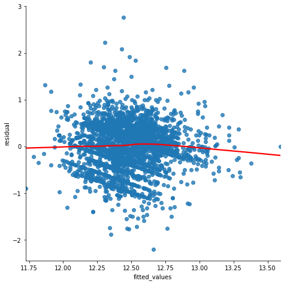

```python
data = pd.DataFrame(dict(fitted_values=SLR_model3.fittedvalues, residual=SLR_model3.resid))
graph = sns.lmplot(x='fitted_values', y='residual', data=data, lowess=True, line_kws={'color':'red'},size=6.5)
plt.show()
```

**Interpretation:Although Visual representation is misleading but according to the test statistic the residuals are heteroskedastic in nature as the Pvalue is less than 0.05**

## 3 out 5 Assumptions of Linear Regression didnt meet up to the mark i.e., Homoskedasticity,Multicollineariy and Normality of Residuals.

**So we perform the Stepwise regression and move to The AI based models of bagging and boosting**

## Applying Stepwise Regression using Feature Selection Technique

```python
from sklearn.linear_model import LinearRegression
from mlxtend.feature_selection import SequentialFeatureSelector as fs
```

```python
LR=LinearRegression()
```

```python
Y=DF_num.Salary
DF_num=DF_num.drop('Salary',axis=1)

X=pd.concat([DF_num,DF_cat],axis=1)
```

```python
X_train_slr, X_test_slr, y_train_slr, y_test_slr = train_test_split(X, np.log(Y),random_state=0, test_size = 0.3)
```

```python
sfs=fs(estimator=LR,k_features='best',scoring='r2',forward=False,cv=5)

sfs=sfs.fit(X_train_slr,y_train_slr)
```

```python
sfs.k_score_
```

```
0.24150680636423108
```

```python
def adjustedRsquared(n,k,Rsquare):
    return 1-((1-Rsquare)*(n-1))/(n-k-1)
```

```python
adj=adjustedRsquared(X_train_slr.shape[0],len(sfs.k_feature_names_),sfs.k_score_)
```

```python
print('Rsquared after applying stepwise regression and few few features:',sfs.k_score_)

print('Adjusted Rsquareafter applying stepwise regression and few few features:',adj)
```

```
Rsquared after applying stepwise regression and few few features: 0.24150680636423108
Adjusted Rsquareafter applying stepwise regression and few few features: 0.23189519818999071
```

```python
x_feature=sfs.k_feature_names_
```

**Building Up Linear Regression model with only those features which are selected by Sequential Feature Selector**

```python
LR=LinearRegression()
scores = cross_val_score(estimator = LR,
                         X = X_train_slr.loc[:,x_feature],
                         y = y_train_slr,
                         cv = 5,
                         scoring = 'r2')
scores
```

```
array([0.22689834, 0.20476958, 0.22666447, 0.22895028, 0.32025137])
```

```python
print('All scores: ', scores)

print("\nMinimum score obtained: ", round(min(scores), 4))

print("Maximum score obtained: ", round(max(scores), 4))

print("Average score obtained: ", round(np.mean(scores), 4))
```

```
All scores:  [0.22689834 0.20476958 0.22666447 0.22895028 0.32025137]

Minimum score obtained:  0.2048
Maximum score obtained:  0.3203
Average score obtained:  0.2415
```

```python
Adjusted_rsq=[]
k=len(x_feature)
for i in scores:
    Adjusted_rsq.append(adjustedRsquared(X_train_slr.shape[0],k,i))
print(Adjusted_rsq)

print("\nMinimum score obtained: ", round(min(Adjusted_rsq), 4))

print("Maximum score obtained: ", round(max(Adjusted_rsq), 4))

print("Average score obtained: ", round(np.mean(Adjusted_rsq), 4))
```

```
[0.2171016123909394, 0.19469243477469267, 0.21686478021606492, 0.2191795508306219, 0.3116376127376338]

Minimum score obtained:  0.1947
Maximum score obtained:  0.3116
Average score obtained:  0.2319
```

**Model with Best Features**

```python
frame=pd.DataFrame({'Rsquared':scores,
             'Adjusted_Rsquare':Adjusted_rsq}).sort_values('Adjusted_Rsquare')
frame
```

|  | Rsquared | Adjusted_Rsquare |
| --- | --- | --- |
| 1 | 0.20477 | 0.19469 |
| 2 | 0.22666 | 0.21686 |
| 0 | 0.22690 | 0.21710 |
| 3 | 0.22895 | 0.21918 |
| 4 | 0.32025 | 0.31164 |

## Regularization

```python
from sklearn.linear_model import Ridge,Lasso
from sklearn.metrics import r2_score
```

### Lasso Regression

```python
X_train_slr, X_test_slr, y_train_slr, y_test_slr = train_test_split(X, np.log(Y),random_state=0, test_size = 0.3)
```

```python
rmse_train=[]
rmse_test=[]
r2=[]
adj_r2=[]
alphas=[0.00001,0.0001,0.001]
al=[]

for i in alphas:
    lasso=Lasso(alpha=i,normalize=True)
    al.append(i)
    pred_tr=lasso.fit(X_train_slr,y_train_slr).predict(X_train_slr)
    pred_ts=lasso.fit(X_train_slr,y_train_slr).predict(X_test_slr)

    rscore=(r2_score(y_train_slr,pred_tr))
    adj_r2.append(adjustedRsquared(X_train_slr.shape[0],X_train_slr.shape[1],rscore))
    r2.append(rscore)

    rmse_train.append(np.sqrt(mean_squared_error(np.exp(y_train_slr),np.exp(pred_tr))))
    rmse_test.append(np.sqrt(mean_squared_error(np.exp(y_test_slr),np.exp(pred_ts))))
```

```python
LassoDF=pd.DataFrame({'Alpha':al,'Rsquare':r2,'Adjusted_R2':adj_r2,'RMSE_train':rmse_train,'RMSE_test':rmse_test })
```

```python
LassoDF['diff']=abs(LassoDF['RMSE_train']-LassoDF['RMSE_test'])
LassoDF.sort_values('diff',ascending=False)
```

|  | Alpha | Rsquare | Adjusted_R2 | RMSE_train | RMSE_test | diff |
| --- | --- | --- | --- | --- | --- | --- |
| 0 | 0.00001 | 0.26615 | 0.24841 | 169396.40536 | 263334.13590 | 93937.73054 |
| 1 | 0.00010 | 0.25929 | 0.24139 | 170347.27131 | 262046.82816 | 91699.55684 |
| 2 | 0.00100 | 0.17111 | 0.15108 | 178091.16354 | 265840.59973 | 87749.43620 |

**At alpha =0.001**

**The most generalized model is achievable when both the training and testing error difference is at least**

**BUT**

**Accuracy wise at alpha 0.00001 The highest Adjusted R2 from Lasso Regression is achieved which just have 6000 more in terms of error difference in Train and Test set**

### Ridge Regression

```python
X_train_slr, X_test_slr, y_train_slr, y_test_slr = train_test_split(X, np.log(Y),random_state=0, test_size = 0.3)
```

```python
rmse_train=[]
rmse_test=[]
r2=[]
adj_r2=[]
alphas=[0.00001,0.0001,0.001,0.01,0.1,0.05,0.5,0.9,1]
al=[]

for i in alphas:
    ridge=Ridge(alpha=i,normalize=True)
    al.append(i)
    pred_tr=ridge.fit(X_train_slr,y_train_slr).predict(X_train_slr)
    pred_ts=ridge.fit(X_train_slr,y_train_slr).predict(X_test_slr)

    rscore=(r2_score(y_train_slr,pred_tr))
    adj_r2.append(adjustedRsquared(X_train_slr.shape[0],X_train_slr.shape[1],rscore))
    r2.append(rscore)

    rmse_train.append(np.sqrt(mean_squared_error(np.exp(y_train_slr),np.exp(pred_tr))))
    rmse_test.append(np.sqrt(mean_squared_error(np.exp(y_test_slr),np.exp(pred_ts))))
```

```python
RidgeDF=pd.DataFrame({'Alpha':al,'Rsquare':r2,'Adjusted_R2':adj_r2,'RMSE_train':rmse_train,'RMSE_test':rmse_test })
```

```python
RidgeDF['diff']=abs(RidgeDF['RMSE_train']-RidgeDF['RMSE_test'])
RidgeDF.sort_values('diff',ascending=False)
```

|  | Alpha | Rsquare | Adjusted_R2 | RMSE_train | RMSE_test | diff |
| --- | --- | --- | --- | --- | --- | --- |
| 0 | 0.00001 | 0.26644 | 0.24871 | 169303.43207 | 263507.29989 | 94203.86782 |
| 1 | 0.00010 | 0.26644 | 0.24871 | 169304.05969 | 263506.51023 | 94202.45054 |
| 2 | 0.00100 | 0.26643 | 0.24871 | 169310.29651 | 263498.52882 | 94188.23232 |
| 3 | 0.01000 | 0.26633 | 0.24860 | 169368.23718 | 263415.44937 | 94047.21220 |
| 5 | 0.05000 | 0.26555 | 0.24780 | 169585.16357 | 263106.89431 | 93521.73074 |
| 4 | 0.10000 | 0.26418 | 0.24640 | 169839.70916 | 262857.38414 | 93017.67498 |
| 6 | 0.50000 | 0.24805 | 0.22988 | 171767.63429 | 262639.93666 | 90872.30237 |
| 7 | 0.90000 | 0.23126 | 0.21268 | 173367.47852 | 263244.94567 | 89877.46715 |
| 8 | 1.00000 | 0.22730 | 0.20863 | 173718.42668 | 263417.57374 | 89699.14706 |

**Interpretation:at alpha =1**

**we get the most generalized model giving the least Train rmse and Test Rmse Diff**

**But**

**Accuracy wise we can take alpha=0.05 which has 4000 error units difference more**

# Decision Tree Regressor

```python
from sklearn.tree import DecisionTreeRegressor as dtr
```

```python
DTR=DecisionTreeRegressor(random_state=123)
```

```python
X_train_slr, X_test_slr, y_train_slr, y_test_slr = train_test_split(X, (Y),random_state=0, test_size = 0.3)
```

```python
DTR_1 =dtr(max_depth=10,max_features=10,random_state=123) # declare the regression model form. Let the depth be default.
model1=DTR_1.fit(X_train_slr,y_train_slr)
```

```python
score = model1.score(X_train_slr,y_train_slr)
print("R-squared:", score)
```

```
R-squared: 0.6098077921549581
```

```python
AdjRsq1=adjustedRsquared(X_train_slr.shape[0],X_train_slr.shape[1],score)
```

```python
y_train_pred=model1.predict(X_train_slr)
y_test_pred=model1.predict(X_test_slr)

RMSE_train1=np.sqrt(mean_squared_error(y_train_slr,y_train_pred))
RMSE_test1=np.sqrt(mean_squared_error(y_test_slr,y_test_pred))
```

```python
print('Model R2 is:',score)
print()
print('Model Adjusted R2 is:',AdjRsq1)
print()
print('RMSE on train data with Decision tree untuned model is:',RMSE_train1)
print()
print('RMSE on test data with Decision Tree untuned model is:',RMSE_test1)
```

```
Model R2 is: 0.6098077921549581

Model Adjusted R2 is: 0.6003780280693585

RMSE on train data with Decision tree untuned model is: 115105.289849602

RMSE on test data with Decision Tree untuned model is: 316019.7894759247
```

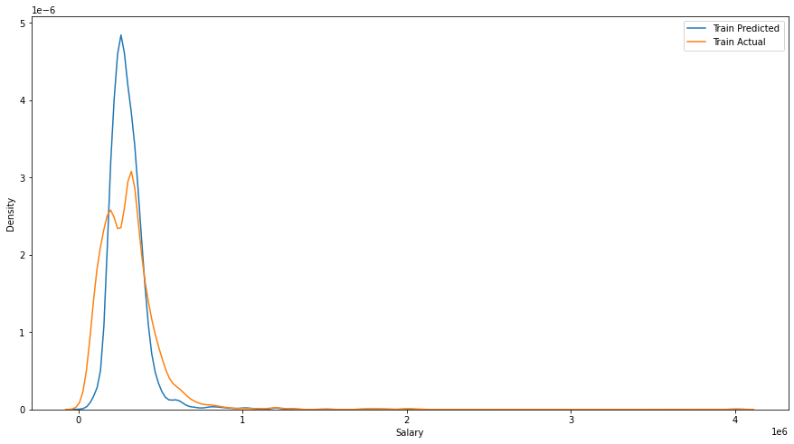

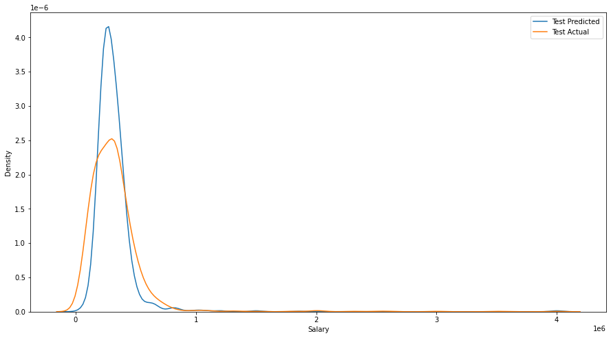

```python
fig,axes=plt.subplots(1,1)
sns.distplot(y_train_pred,label='Train Predicted',hist=False)
sns.distplot(y_train_slr,label='Train Actual',hist=False)
plt.legend()

fig,axes=plt.subplots(1,1)
sns.distplot((y_test_pred),label='Test Predicted',hist=False)
sns.distplot((y_test_slr),label='Test Actual',hist=False)
plt.legend()
```

### Hyperparameter Tuning

```python
tunned_paramaters=[{
                     'max_depth': range(5,10),
                     'max_features': range(10,18),
                     }]

DTR2 = DecisionTreeRegressor(random_state = 0)


tree_grid = RandomizedSearchCV(estimator = DTR2,
                         param_distributions= tunned_paramaters,
                         cv = 5,n_iter=10)


tree_grid_model = tree_grid.fit(X_train_slr, y_train_slr)

print('Best parameters for decision tree Regressor: ', tree_grid_model.best_params_, '\n')
```

```
Best parameters for decision tree Regressor:  {'max_features': 13, 'max_depth': 7}
```

```python
from sklearn.tree import DecisionTreeRegressor as dtr

DT_hyp = dtr(**tree_grid_model.best_params_,random_state=0)
DTmodel2=DT_hyp.fit(X_train_slr,y_train_slr)

y_train_pred=DTmodel2.predict(X_train_slr)
y_test_pred=DTmodel2.predict(X_test_slr)
```

```python
score2 = DTmodel2.score(X_train_slr, y_train_slr)
print("R-squared:", score2)

Train_rmse=np.sqrt(mean_squared_error(y_train_slr,y_train_pred))

Test_rmse=np.sqrt(mean_squared_error(y_test_slr,y_test_pred))
```

```
R-squared: 0.4301859760869714
```

```python
AdjRsq2=adjustedRsquared(X_train_slr.shape[0],X_train_slr.shape[1],score2)

y_train_pred=DTmodel2.predict(X_train_slr)
y_test_pred=DTmodel2.predict(X_test_slr)

print('Model R2 is:',score2)
print()
print('Model Adjusted R2 is:',AdjRsq2)
print()
print('RMSE on train data with Decision Tree tuned model is:', Train_rmse)
print()
print('RMSE on test data with Decision Tree tuned model is:',Test_rmse)
```

```
Model R2 is: 0.4301859760869714

Model Adjusted R2 is: 0.41641529663685795

RMSE on train data with Decision Tree tuned model is: 139098.5341961172

RMSE on test data with Decision Tree tuned model is: 270766.12934695097
```

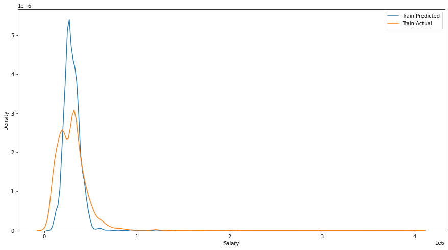

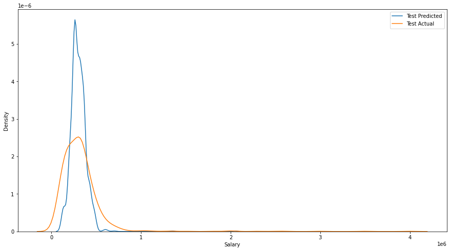

```python
fig,axes=plt.subplots(1,1)
sns.distplot(y_train_pred,label='Train Predicted',hist=False)
sns.distplot((y_train_slr),label='Train Actual',hist=False)
plt.legend()

fig,axes=plt.subplots(1,1)
sns.distplot((y_test_pred),label='Test Predicted',hist=False)
sns.distplot((y_test_slr),label='Test Actual',hist=False)
plt.legend()
```

```python
DT_frame=pd.DataFrame({'Model Name':['Decision_Tree_untuned','Decision_Tree_tuned'],
                      'Rsquare':[score,score2],
                      'Adjusted_Rsq':[AdjRsq1,AdjRsq2],
                      'Train RMSE':[RMSE_train1,Train_rmse],
                      'Test RMSE':[RMSE_test1,Test_rmse]})
DT_frame
```

|  | Model Name | Rsquare | Adjusted_Rsq | Train RMSE | Test RMSE |
| --- | --- | --- | --- | --- | --- |
| 0 | Decision_Tree_untuned | 0.60981 | 0.60038 | 115105.28985 | 316019.78948 |
| 1 | Decision_Tree_tuned | 0.43019 | 0.41642 | 139098.53420 | 270766.12935 |

```python
DT_frame['diff']=abs(DT_frame['Train RMSE']-DT_frame['Test RMSE'])
DT_frame.sort_values('diff',ascending=False)
```

|  | Model Name | Rsquare | Adjusted_Rsq | Train RMSE | Test RMSE | diff |
| --- | --- | --- | --- | --- | --- | --- |
| 0 | Decision_Tree_untuned | 0.60981 | 0.60038 | 115105.28985 | 316019.78948 | 200914.49963 |
| 1 | Decision_Tree_tuned | 0.43019 | 0.41642 | 139098.53420 | 270766.12935 | 131667.59515 |

## Random Forest Regressor

**As the Tree Based Models are robust to ouliers**

**The algorithm even works well on the data with outliers/skewed.**

```python
X_train_slr, X_test_slr, y_train_slr, y_test_slr = train_test_split(X, (Y),random_state=0, test_size = 0.3)
```

```python
from sklearn.ensemble import RandomForestRegressor as RFR

regressor = RFR(n_estimators = 100, random_state = 0)
Rfmodel1=regressor.fit(X_train_slr,y_train_slr)

score = Rfmodel1.score(X_train_slr,y_train_slr)
print("R-squared:", score)
```

```
R-squared: 0.8691565573403818
```

```python
AdjRsq=adjustedRsquared(X_train_slr.shape[0],X_train_slr.shape[1],score)

y_train_pred=Rfmodel1.predict(X_train_slr)
y_test_pred=Rfmodel1.predict(X_test_slr)

RF1score=score

RF1adj_score=AdjRsq

Train_RMSE_1=np.sqrt(mean_squared_error(y_train_slr,y_train_pred))
Test_RMSE_1=np.sqrt(mean_squared_error(y_test_slr,y_test_pred))
```

```python
print('Model R2 is:',RF1score)
print()
print('Model Adjusted R2 is:',AdjRsq)
print()
print('RMSE on train data with Random Forest untuned model is:', Train_RMSE_1)
print()
print('RMSE on test data with Random Forest untuned model is:',Test_RMSE_1)
```

```
Model R2 is: 0.8691565573403818

Model Adjusted R2 is: 0.8659944675507315

RMSE on train data with Random Forest untuned model is: 66654.88260823979

RMSE on test data with Random Forest untuned model is: 266546.89622450434
```

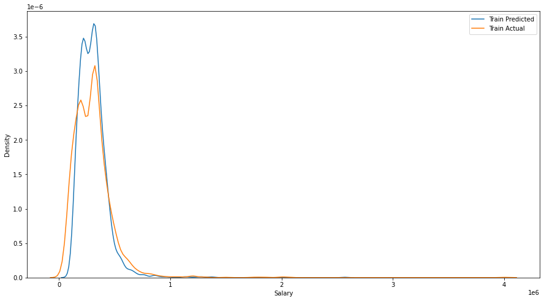

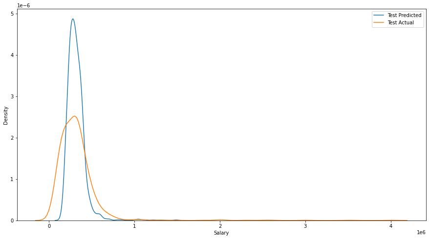

```python
fig,axes=plt.subplots(1,1)
sns.distplot((y_train_pred),label='Train Predicted',hist=False)
sns.distplot((y_train_slr),label='Train Actual',hist=False)
plt.legend()

fig,axes=plt.subplots(1,1)
sns.distplot((y_test_pred),label='Test Predicted',hist=False)
sns.distplot((y_test_slr),label='Test Actual',hist=False)
plt.legend()
```

**Interpretation:Highly Overfitted model so we tune the hyperparameters**

**Hyperparameter Tuning**

```python
# Range of hyperparameter,log(y)
```

```python
tunned_paramaters=[{
                    'max_depth': range(5,20),
                     'max_features': range(5,20),
                        'min_samples_split':range(5,20)
                     }]

regress = RFR(random_state = 123,n_estimators=100)


Forest_grid = RandomizedSearchCV(estimator = regress,
                         param_distributions= tunned_paramaters,
                         cv = 5,n_iter=10)


Forest_grid_model = Forest_grid.fit(X_train_slr, y_train_slr)

print('Best parameters for Random tree Regressor: ', Forest_grid_model.best_params_, '\n')
```

```
Best parameters for Random tree Regressor:  {'min_samples_split': 14, 'max_features': 12, 'max_depth': 12}
```

```python
# {'min_samples_split': 17, 'max_features': 5, 'max_depth': 14}
```

```python
regressor = RFR(**Forest_grid_model.best_params_)
Rfmodel2=regressor.fit(X_train_slr,y_train_slr)

Rf2score= Rfmodel2.score(X_train_slr, y_train_slr)
print("R-squared:", Rf2score)
```

```
R-squared: 0.5046517012620786
```

```python
AdjRsq_2=adjustedRsquared(X_train_slr.shape[0],X_train_slr.shape[1],Rf2score)

y_train_pred=Rfmodel2.predict(X_train_slr)
y_test_pred=Rfmodel2.predict(X_test_slr)

train_rmse=np.sqrt(mean_squared_error(y_train_slr,y_train_pred))

test_rmse=np.sqrt(mean_squared_error(y_test_slr,y_test_pred))
```

```python
print('Model R2 is:',Rf2score)
print()
print('Model Adjusted R2 is:',AdjRsq_2)
print()
print('RMSE on train data with Random Forest Tuned model is:', train_rmse)
print()
print('RMSE on test data with Random Forest Tuned  model is:',test_rmse)
```

```
Model R2 is: 0.5046517012620786

Model Adjusted R2 is: 0.4926806328927257

RMSE on train data with Random Forest Tuned model is: 129691.44363326413

RMSE on test data with Random Forest Tuned  model is: 257444.60171175378
```

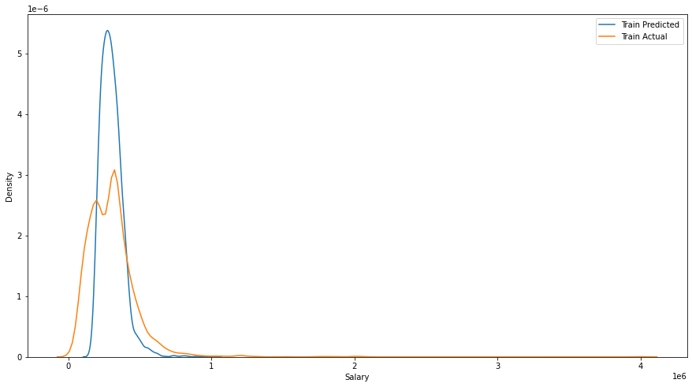

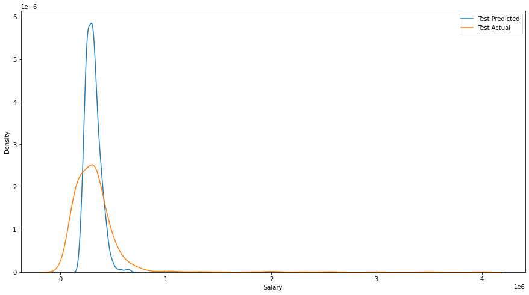

```python
fig,axes=plt.subplots(1,1)
sns.distplot((y_train_pred),label='Train Predicted',hist=False)
sns.distplot((y_train_slr),label='Train Actual',hist=False)
plt.legend()

fig,axes=plt.subplots(1,1)
sns.distplot((y_test_pred),label='Test Predicted',hist=False)
sns.distplot((y_test_slr),label='Test Actual',hist=False)
plt.legend()
```

```python
X_train_slr, X_test_slr, y_train_slr, y_test_slr = train_test_split(X, np.log(Y),random_state=0, test_size = 0.3)
```

```python
tunned_paramaters=[{
                    'max_depth': range(5,20),
                     'max_features': range(5,20),
                        'min_samples_split':range(5,20)
                     }]

regress = RFR(random_state = 123,n_estimators=100)


Forest_grid_2 = RandomizedSearchCV(estimator = regress,
                         param_distributions= tunned_paramaters,
                         cv = 5,n_iter=10)


Forest_grid_model_log = Forest_grid_2.fit(X_train_slr, y_train_slr)

print('Best parameters for Random tree Regressor: ', Forest_grid_model_log.best_params_, '\n')
```

```
Best parameters for Random tree Regressor:  {'min_samples_split': 12, 'max_features': 12, 'max_depth': 15}
```

```python
regressor_1 = RFR(**Forest_grid_model_log.best_params_)
Rfmodel3=regressor.fit(X_train_slr,y_train_slr)

Rf3score= Rfmodel3.score(X_train_slr, y_train_slr)
print("R-squared:", Rf3score)
```

```
R-squared: 0.577450784453011
```

```python
AdjRsq_3=adjustedRsquared(X_train_slr.shape[0],X_train_slr.shape[1],Rf3score)

y_train_pred=Rfmodel3.predict(X_train_slr)
y_test_pred=Rfmodel3.predict(X_test_slr)

train_rmse_3=np.sqrt(mean_squared_error(np.exp(y_train_slr),np.exp(y_train_pred)))

test_rmse_3=np.sqrt(mean_squared_error(np.exp(y_test_slr),np.exp(y_test_pred)))
```

```python
print('Model R2 is:',Rf3score)
print()
print('Model Adjusted R2 is:',AdjRsq_3)
print()
print('RMSE on train data with Random Forest Tuned model with log(Salary) is:', train_rmse_3)
print()
print('RMSE on test data with Random Forest Tuned  model with log(Salary) is:',test_rmse_3)
```

```
Model R2 is: 0.577450784453011

Model Adjusted R2 is: 0.5672390494745778

RMSE on train data with Random Forest Tuned model with log(Salary) is: 142251.72875062763

RMSE on test data with Random Forest Tuned  model with log(Salary) is: 261105.3542665783
```

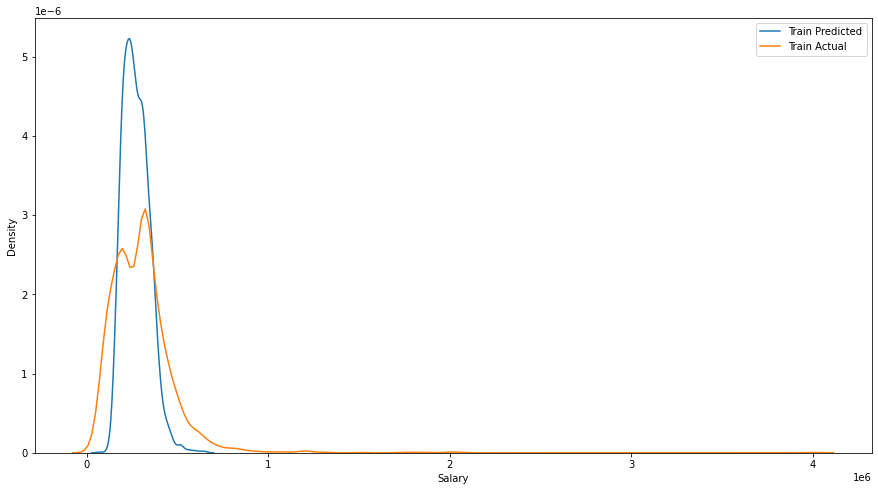

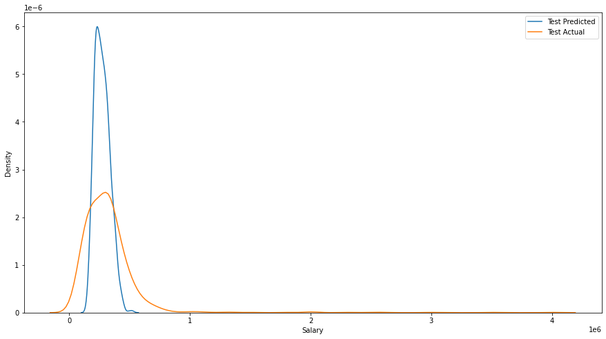

```python
fig,axes=plt.subplots(1,1)
sns.distplot(np.exp(y_train_pred),label='Train Predicted',hist=False)
sns.distplot(np.exp(y_train_slr),label='Train Actual',hist=False)
plt.legend()

fig,axes=plt.subplots(1,1)
sns.distplot(np.exp(y_test_pred),label='Test Predicted',hist=False)
sns.distplot(np.exp(y_test_slr),label='Test Actual',hist=False)
plt.legend()
```

```python
RF_frame=pd.DataFrame({'Model Name':['RF_untuned','RF_tuned','RF_tuned_log'],
                      'Rsquare':[RF1score,Rf2score,Rf3score],
                      'Adjusted_Rsq':[RF1adj_score,AdjRsq_2,AdjRsq_3],
                      'Train RMSE':[Train_RMSE_1,train_rmse,train_rmse_3],
                      'Test RMSE':[Test_RMSE_1,test_rmse,test_rmse_3]})
RF_frame['diff']=abs(RF_frame['Train RMSE']-RF_frame['Test RMSE'])

RF_frame.sort_values('diff',ascending=False)
```

|  | Model Name | Rsquare | Adjusted_Rsq | Train RMSE | Test RMSE | diff |
| --- | --- | --- | --- | --- | --- | --- |
| 0 | RF_untuned | 0.86916 | 0.86599 | 66654.88261 | 266546.89622 | 199892.01362 |
| 1 | RF_tuned | 0.50465 | 0.49268 | 129691.44363 | 257444.60171 | 127753.15808 |
| 2 | RF_tuned_log | 0.57745 | 0.56724 | 142251.72875 | 261105.35427 | 118853.62552 |

## Gradient Boosting Regressor

```python
from sklearn.ensemble import GradientBoostingRegressor
```

```python
X_train_slr, X_test_slr, y_train_slr, y_test_slr = train_test_split(X, (Y),random_state=0, test_size = 0.3)
```

```python
gbr = GradientBoostingRegressor(criterion='mse',random_state=10)
gbmodel1=gbr.fit(X_train_slr, y_train_slr)
rsq_gb=gbmodel1.score(X_train_slr,y_train_slr)

ytrain_pred = gbmodel1.predict(X_train_slr)
ytest_pred =gbmodel1.predict(X_test_slr)

aDj_=adjustedRsquared(X_train_slr.shape[0],X_train_slr.shape[1],rsq_gb)
```

```python
train_gb_rmse=np.sqrt(mean_squared_error(y_train_slr,ytrain_pred))

test_gb_rmse=np.sqrt(mean_squared_error(y_test_slr,ytest_pred))
```

```python
print('Model R2 is:',rsq_gb)
print()
print('Model Adjusted R2 is:',aDj_)
print()
print('RMSE on train data with Gradient Boosting untuned model is:', train_gb_rmse)
print()
print('RMSE on test data with Gradient Boosting untuned model is:',test_gb_rmse)
```

```
Model R2 is: 0.5278040606065728

Model Adjusted R2 is: 0.5163925146527222

RMSE on train data with Gradient Boosting untuned model is: 126624.31550472332

RMSE on test data with Gradient Boosting untuned model is: 264922.5415253693
```

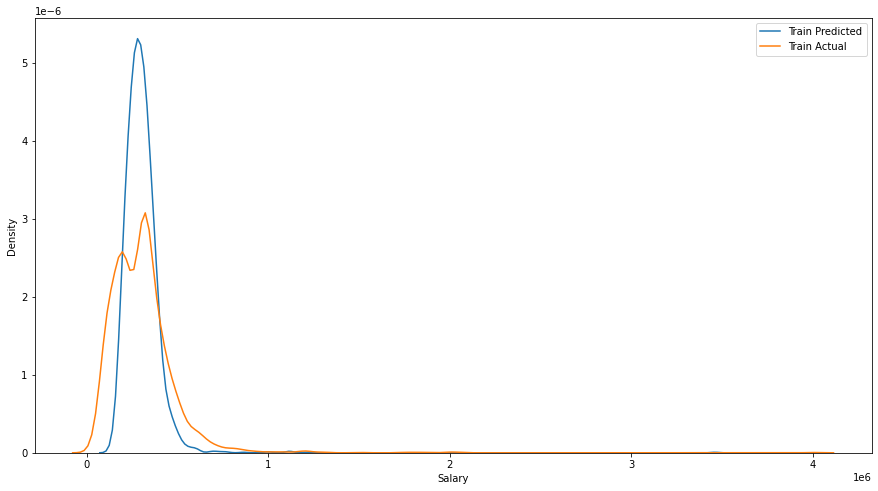

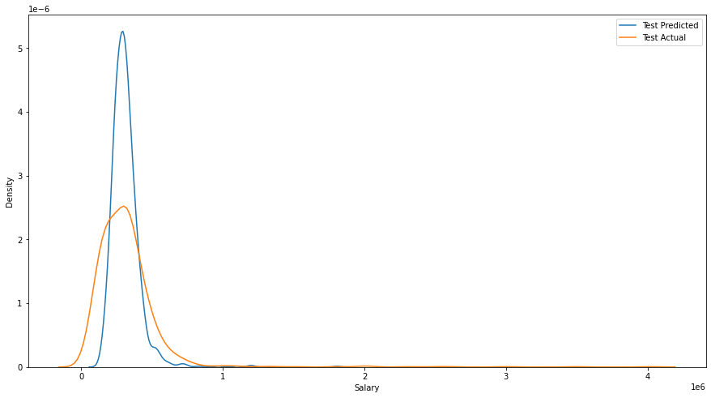

```python
fig,axes=plt.subplots(1,1)
sns.distplot((ytrain_pred),label='Train Predicted',hist=False)
sns.distplot((y_train_slr),label='Train Actual',hist=False)
plt.legend()

fig,axes=plt.subplots(1,1)
sns.distplot((ytest_pred),label='Test Predicted',hist=False)
sns.distplot((y_test_slr),label='Test Actual',hist=False)
plt.legend()
```

**Hyperparamter tuning**

```python
X_train_slr, X_test_slr, y_train_slr, y_test_slr = train_test_split(X, (Y),random_state=0, test_size = 0.3)
```

```python
tuned_parameters=[{ 'learning_rate':[0.01,0.1,0.5,0.9,1],
                   'n_estimators':[40,50,70,100]
}]

GBRT=GradientBoostingRegressor(criterion='mse',random_state=123)

GBR_grid=RandomizedSearchCV(estimator=GBRT,param_distributions=tuned_parameters
                           ,cv=5,n_iter=10)
GBR_model=GBR_grid.fit(X_train_slr,y_train_slr)

print('Best hyperparameters for Gradient Boosting is',GBR_grid.best_params_,'\n')
```

```
Best hyperparameters for Gradient Boosting is {'n_estimators': 70, 'learning_rate': 0.1}
```

```python
GBR_model_tuned=GradientBoostingRegressor(random_state=0,**GBR_grid.best_params_)

GBRT_mod=GBR_model_tuned.fit(X_train_slr,y_train_slr)

GBR_score=GBRT_mod.score(X_train_slr,y_train_slr)
```

```python
adj_r2_gbrt=adjustedRsquared(X_train_slr.shape[0],X_train_slr.shape[1],GBR_score)
y_pred_train=GBRT_mod.predict(X_train_slr)
y_pred_test=GBRT_mod.predict(X_test_slr)
```

```python
train_gbt_rmse=np.sqrt(mean_squared_error(y_train_slr,y_pred_train))

test_gbt_rmse=np.sqrt(mean_squared_error(y_test_slr,y_pred_test))
```

```python
print('Model R2 is:',GBR_score)
print()
print('Model Adjusted R2 is:',adj_r2_gbrt)
print()
print('RMSE on train data with Gradient Boosting tuned model is:', train_gbt_rmse)
print()
print('RMSE on test data with Gradient Boosting tuned model is:',test_gbt_rmse)
```

```
Model R2 is: 0.47754194784525184

Model Adjusted R2 is: 0.4649157188294285

RMSE on train data with Gradient Boosting tuned model is: 133193.0917544807

RMSE on test data with Gradient Boosting tuned model is: 262166.2140979212
```

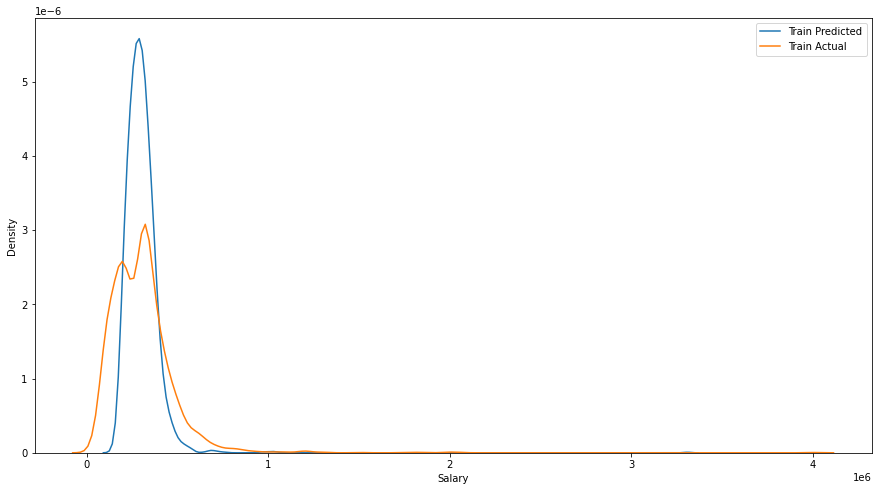

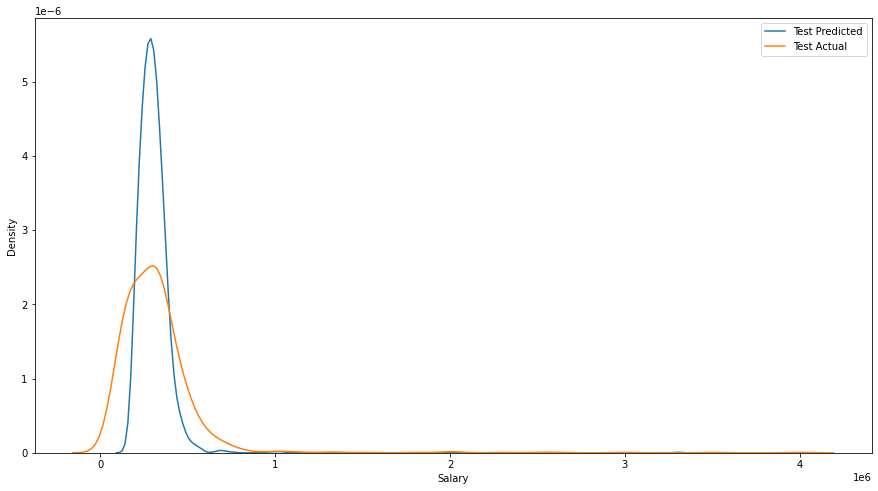

```python
fig,axes=plt.subplots(1,1)
sns.distplot((y_pred_train),label='Train Predicted',hist=False)
sns.distplot((y_train_slr),label='Train Actual',hist=False)
plt.legend()

fig,axes=plt.subplots(1,1)
sns.distplot((y_pred_train),label='Test Predicted',hist=False)
sns.distplot((y_test_slr),label='Test Actual',hist=False)
plt.legend()
```

```python
X_train_slr, X_test_slr, y_train_slr, y_test_slr = train_test_split(X, np.log(Y),random_state=0, test_size = 0.3)

tuned_parameters=[{ 'learning_rate':[0.01,0.1,0.5,0.9,1],
                   'n_estimators':[70,80,100]
}]

GBRT_2=GradientBoostingRegressor(criterion='mse',random_state=123)

GBR_grid_2=RandomizedSearchCV(estimator=GBRT_2,param_distributions=tuned_parameters
                           ,cv=5,n_iter=10)
GBR_model_2=GBR_grid_2.fit(X_train_slr,y_train_slr)

print('Best hyperparameters for Gradient Boosting is',GBR_grid_2.best_params_,'\n')
```

```
Best hyperparameters for Gradient Boosting is {'n_estimators': 70, 'learning_rate': 0.1}
```

```python
GBR_model_tuned_2=GradientBoostingRegressor(random_state=0,**GBR_grid_2.best_params_)

GBRT_mod_2=GBR_model_tuned_2.fit(X_train_slr,y_train_slr)

GBR_score_2=GBRT_mod_2.score(X_train_slr,y_train_slr)
```

```python
adj_r2_gbrt_2=adjustedRsquared(X_train_slr.shape[0],X_train_slr.shape[1],GBR_score_2)
y_pred_train=GBRT_mod_2.predict(X_train_slr)
y_pred_test=GBRT_mod_2.predict(X_test_slr)

train_gbt_rmse_2=np.sqrt(mean_squared_error(np.exp(y_train_slr),np.exp(y_pred_train)))

test_gbt_rmse_2=np.sqrt(mean_squared_error(np.exp(y_test_slr),np.exp(y_pred_test)))
```

```python
print('Model R2 is:',GBR_score_2)
print()
print('Model Adjusted R2 is:',adj_r2_gbrt_2)
print()
print('RMSE on train data with Gradient Boosting tuned model is:', train_gbt_rmse_2)
print()
print('RMSE on test data with Gradient Boosting tuned model is:',test_gbt_rmse_2)
```

```
Model R2 is: 0.38369179854596314

Model Adjusted R2 is: 0.36879749561811015

RMSE on train data with Gradient Boosting tuned model is: 157478.02267292046

RMSE on test data with Gradient Boosting tuned model is: 260299.16098746823
```

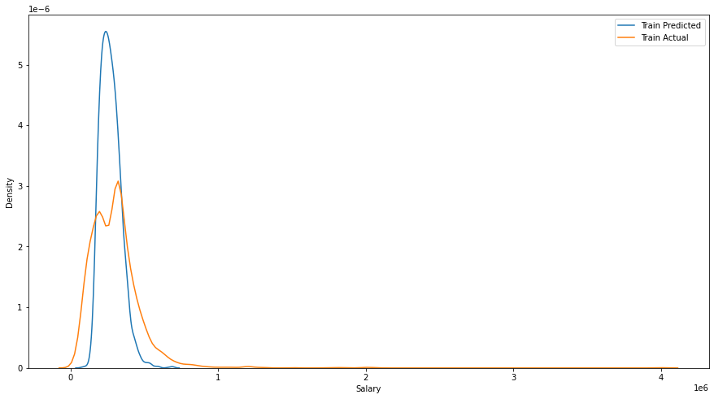

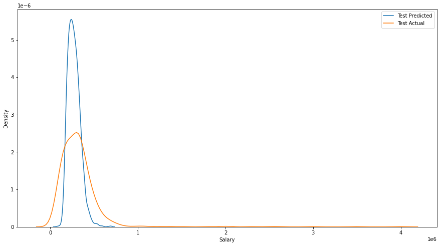

```python
fig,axes=plt.subplots(1,1)
sns.distplot(np.exp(y_pred_train),label='Train Predicted',hist=False)
sns.distplot(np.exp(y_train_slr),label='Train Actual',hist=False)
plt.legend()

fig,axes=plt.subplots(1,1)
sns.distplot(np.exp(y_pred_train),label='Test Predicted',hist=False)
sns.distplot(np.exp(y_test_slr),label='Test Actual',hist=False)
plt.legend()
```

```python
GB_frame=pd.DataFrame({'Model Name':['GradientBoosting_untuned','GradientBoosting_tuned','GradientBoosting_tuned_log'],
                      'Rsquare':[rsq_gb,GBR_score,GBR_score_2],
                      'Adjusted_Rsq':[aDj_,adj_r2_gbrt,adj_r2_gbrt_2],
                      'Train RMSE':[train_gb_rmse,train_gbt_rmse,train_gbt_rmse_2],
                      'Test RMSE':[test_gb_rmse,test_gbt_rmse,test_gbt_rmse_2]})
GB_frame['diff']=abs(GB_frame['Train RMSE']-GB_frame['Test RMSE'])

GB_frame.sort_values('Rsquare',ascending=False)
```

|  | Model Name | Rsquare | Adjusted_Rsq | Train RMSE | Test RMSE | diff |
| --- | --- | --- | --- | --- | --- | --- |
| 0 | GradientBoosting_untuned | 0.52780 | 0.51639 | 126624.31550 | 264922.54153 | 138298.22602 |
| 1 | GradientBoosting_tuned | 0.47754 | 0.46492 | 133193.09175 | 262166.21410 | 128973.12234 |
| 2 | GradientBoosting_tuned_log | 0.38369 | 0.36880 | 157478.02267 | 260299.16099 | 102821.13831 |

## Xtreme Gradient Boosting

```python
import xgboost as xgb
```

```python
X_train_slr, X_test_slr, y_train_slr, y_test_slr = train_test_split(X, (Y),random_state=0, test_size = 0.3)
```

```python
XGB1=xgb.XGBRegressor(n_estimators=100,random_state=123)

XGBmod1=XGB1.fit(X_train_slr,y_train_slr)

XGB1_score=XGBmod1.score(X_train_slr,y_train_slr)
```

```python
adj_XGB1=adjustedRsquared(X_train_slr.shape[0],X_train_slr.shape[1],XGB1_score)

y_pred_train=XGBmod1.predict(X_train_slr)
y_pred_test=XGBmod1.predict(X_test_slr)
```

```python
train_xgb1_rmse=np.sqrt(mean_squared_error(y_train_slr,y_pred_train))

test_xgb1_rmse=np.sqrt(mean_squared_error(y_test_slr,y_pred_test))
```

```python
print('Model R2 is:',XGB1_score)
print()
print('Model Adjusted R2 is:',adj_XGB1)
print()
print('RMSE on train data with XGBoost untuned model is:', train_xgb1_rmse)
print()
print('RMSE on test data with XGBoost untuned model is:',test_xgb1_rmse)
```

```
Model R2 is: 0.9654639820698117

Model Adjusted R2 is: 0.9646293510982289

RMSE on train data with XGBoost untuned model is: 34244.60153744477

RMSE on test data with XGBoost untuned model is: 263292.9431546032
```

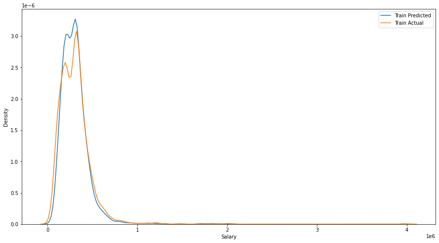

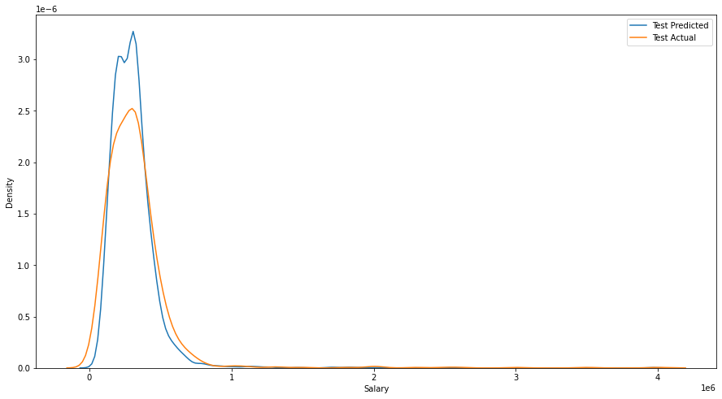

```python
fig,axes=plt.subplots(1,1)
sns.distplot((y_pred_train),label='Train Predicted',hist=False)
sns.distplot((y_train_slr),label='Train Actual',hist=False)
plt.legend()

fig,axes=plt.subplots(1,1)
sns.distplot((y_pred_train),label='Test Predicted',hist=False)
sns.distplot((y_test_slr),label='Test Actual',hist=False)
plt.legend()
```

**HyperParameter Tuning**

```python
X_train_slr, X_test_slr, y_train_slr, y_test_slr = train_test_split(X, (Y),random_state=0, test_size = 0.3)
```

```python
tuned_parameters=[{ 'learning_rate':[0.01,0.1,0.5,0.9,1],
                   'n_estimators':[50,70,90,100]
}]

XGBT=xgb.XGBRegressor(random_state=123)

XGB_grid=RandomizedSearchCV(estimator=XGBT,param_distributions=tuned_parameters
                           ,cv=5,n_iter=10)
XGB_model=XGB_grid.fit(X_train_slr,y_train_slr)

print('Best hyperparameters for Gradient Boosting is',XGB_grid.best_params_,'\n')
```

```
Best hyperparameters for Gradient Boosting is {'n_estimators': 50, 'learning_rate': 0.1}
```

```python
XGBT=xgb.XGBRegressor(random_state=123,**XGB_grid.best_params_)

XGBmod2=XGBT.fit(X_train_slr,y_train_slr)

XGB2_score=XGBmod2.score(X_train_slr,y_train_slr)

adj_XGB2=adjustedRsquared(X_train_slr.shape[0],X_train_slr.shape[1],XGB2_score)

y_pred_train=XGBmod2.predict(X_train_slr)
y_pred_test=XGBmod2.predict(X_test_slr)

train_xgb2_rmse=np.sqrt(mean_squared_error(y_train_slr,y_pred_train))

test_xgb2_rmse=np.sqrt(mean_squared_error(y_test_slr,y_pred_test))
```

```python
print('Model R2 is:',XGB2_score)
print()
print('Model Adjusted R2 is:',adj_XGB2)
print()
print('RMSE on train data with XGBoost tuned model is:', train_xgb2_rmse)
print()
print('RMSE on test data with XGBoost tuned model is:',test_xgb2_rmse)
```

```
Model R2 is: 0.6865521207432161

Model Adjusted R2 is: 0.6789770346828179

RMSE on train data with XGBoost tuned model is: 103166.4899127878

RMSE on test data with XGBoost tuned model is: 259238.7748004897
```

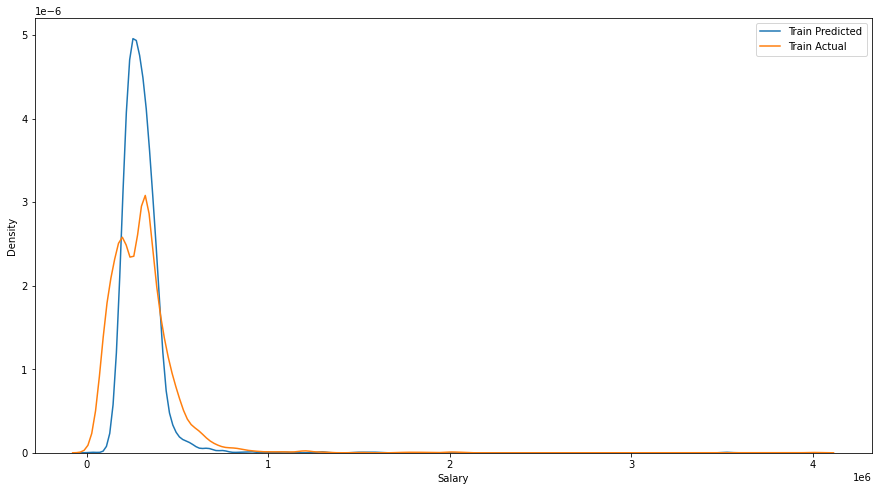

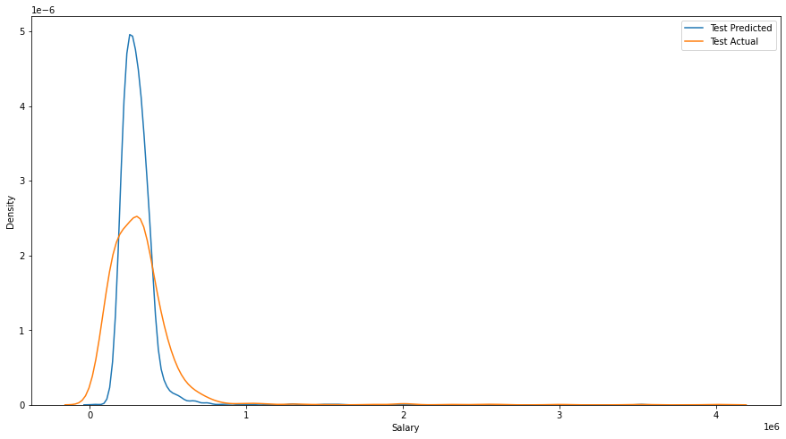

```python
fig,axes=plt.subplots(1,1)
sns.distplot((y_pred_train),label='Train Predicted',hist=False)
sns.distplot((y_train_slr),label='Train Actual',hist=False)
plt.legend()

fig,axes=plt.subplots(1,1)
sns.distplot((y_pred_train),label='Test Predicted',hist=False)
sns.distplot((y_test_slr),label='Test Actual',hist=False)
plt.legend()
```

```python
X_train_slr, X_test_slr, y_train_slr, y_test_slr = train_test_split(X, np.log(Y),random_state=0, test_size = 0.3)

tuned_parameters=[{ 'learning_rate':[0.01,0.1,0.5,0.9,1],
                   'n_estimators':[50,70,90,100]
}]

XGBT_2=xgb.XGBRegressor(random_state=123)

XGB_grid_2=RandomizedSearchCV(estimator=XGBT_2,param_distributions=tuned_parameters
                           ,cv=5,n_iter=10)
XGB_model_2=XGB_grid_2.fit(X_train_slr,y_train_slr)

print('Best hyperparameters for Gradient Boosting is',XGB_grid_2.best_params_,'\n')
```

```
Best hyperparameters for Gradient Boosting is {'n_estimators': 100, 'learning_rate': 0.1}
```

```python
XGBT_2log=xgb.XGBRegressor(random_state=123,**XGB_grid_2.best_params_)

XGBmod2=XGBT_2log.fit(X_train_slr,y_train_slr)

XGBTT_score=XGBmod2.score(X_train_slr,y_train_slr)

adj_XGB_2T_=adjustedRsquared(X_train_slr.shape[0],X_train_slr.shape[1],XGBTT_score)

y_pred_train=XGBmod2.predict(X_train_slr)
y_pred_test=XGBmod2.predict(X_test_slr)

train_xgb2log_rmse=np.sqrt(mean_squared_error(np.exp(y_train_slr),np.exp(y_pred_train)))

test_xgb2log_rmse=np.sqrt(mean_squared_error(np.exp(y_test_slr),np.exp(y_pred_test)))

print('Model R2 is:',XGBTT_score)
print()
print('Model Adjusted R2 is:',adj_XGB_2T_)
print()
print('RMSE on train data with XGBoost tuned model is:', train_xgb2log_rmse)
print()
print('RMSE on test data with XGBoost tuned model is:',test_xgb2log_rmse)
```

```
Model R2 is: 0.7046122718935313

Model Adjusted R2 is: 0.6974736449967802

RMSE on train data with XGBoost tuned model is: 112933.09288193664

RMSE on test data with XGBoost tuned model is: 260742.8390188974
```

```python
XGB_frame=pd.DataFrame({'Model Name':['XGBoost_untuned','XGBoost_tuned','XGBoost_log_tuned'],
                      'Rsquare':[XGB1_score,XGB2_score,XGBTT_score],
                      'Adjusted_Rsq':[adj_XGB1,adj_XGB2,adj_XGB_2T_],
                      'Train RMSE':[train_xgb1_rmse,train_xgb2_rmse,train_xgb2log_rmse],
                      'Test RMSE':[test_xgb1_rmse,test_xgb2_rmse,test_xgb2log_rmse]})
XGB_frame['diff']=abs(XGB_frame['Train RMSE']-XGB_frame['Test RMSE'])

XGB_frame.sort_values('diff',ascending=False)
```

|  | Model Name | Rsquare | Adjusted_Rsq | Train RMSE | Test RMSE | diff |
| --- | --- | --- | --- | --- | --- | --- |
| 0 | XGBoost_untuned | 0.96546 | 0.96463 | 34244.60154 | 263292.94315 | 229048.34162 |
| 1 | XGBoost_tuned | 0.68655 | 0.67898 | 103166.48991 | 259238.77480 | 156072.28489 |
| 2 | XGBoost_log_tuned | 0.70461 | 0.69747 | 112933.09288 | 260742.83902 | 147809.74614 |

# Applying PCA

```python
X_non_scaled=DF_num.iloc[:,[0,1,2,3,4,5,7,8,9,10,11,12,13,19]]
X_scaled=DF_num.iloc[:,[6,14,15,16,17,18]]
```

```python
from sklearn.preprocessing import StandardScaler
from sklearn.decomposition import PCA
SS=StandardScaler()
```

```python
X_scaled1=pd.DataFrame(SS.fit_transform(X_non_scaled),columns=X_non_scaled.columns)
X_scaled1.head()
```

|  | 10percentage | 12percentage | collegeGPA | English | Logical | Quant | ComputerProgramming | ElectronicsAndSemicon | ComputerScience | MechanicalEngg | ElectricalEngg | TelecomEngg | CivilEngg | Age |
| --- | --- | --- | --- | --- | --- | --- | --- | --- | --- | --- | --- | --- | --- | --- |
| 0 | 0.64723 | 1.93968 | 0.79765 | 0.12724 | 0.96115 | 0.09504 | 0.44732 | -0.60868 | -0.52341 | -0.24434 | -0.19956 | -0.31330 | -0.10049 | -1.00262 |
| 1 | 0.75892 | 0.95773 | -0.17464 | 1.84272 | 1.24926 | 2.18029 | -1.72389 | 2.34467 | -0.52341 | -0.24434 | -0.19956 | -0.31330 | -0.10049 | 0.69373 |
| 2 | 0.71831 | -0.56974 | -0.18199 | 1.08028 | 0.50017 | -1.17247 | 0.20336 | -0.60868 | -0.52341 | -0.24434 | -0.19956 | -0.31330 | -0.10049 | -0.15444 |
| 3 | 0.77923 | 0.83044 | 0.38620 | 1.27089 | 0.96115 | 0.91279 | 1.27677 | -0.60868 | -0.52341 | -0.24434 | -0.19956 | -0.31330 | -0.10049 | -0.15444 |
| 4 | 0.00757 | 0.21218 | 0.29558 | 0.41315 | 1.42212 | -0.39561 | -1.72389 | 0.86799 | -0.52341 | -0.24434 | -0.19956 | -0.31330 | -0.10049 | -1.00262 |

```python
X_std=pd.concat([X_scaled1,X_scaled],axis=1)
X_std.head()
```

|  | 10percentage | 12percentage | collegeGPA | English | Logical | Quant | ComputerProgramming | ElectronicsAndSemicon | ComputerScience | MechanicalEngg | ElectricalEngg | TelecomEngg | CivilEngg | Age | Domain | conscientiousness | agreeableness | extraversion | nueroticism | openess_to_experience |
| --- | --- | --- | --- | --- | --- | --- | --- | --- | --- | --- | --- | --- | --- | --- | --- | --- | --- | --- | --- | --- |
| 0 | 0.64723 | 1.93968 | 0.79765 | 0.12724 | 0.96115 | 0.09504 | 0.44732 | -0.60868 | -0.52341 | -0.24434 | -0.19956 | -0.31330 | -0.10049 | -1.00262 | 0.63598 | 0.97370 | 0.81280 | 0.52690 | 1.35490 | -0.44550 |
| 1 | 0.75892 | 0.95773 | -0.17464 | 1.84272 | 1.24926 | 2.18029 | -1.72389 | 2.34467 | -0.52341 | -0.24434 | -0.19956 | -0.31330 | -0.10049 | 0.69373 | 0.96060 | -0.73350 | 0.37890 | 1.23960 | -0.10760 | 0.86370 |
| 2 | 0.71831 | -0.56974 | -0.18199 | 1.08028 | 0.50017 | -1.17247 | 0.20336 | -0.60868 | -0.52341 | -0.24434 | -0.19956 | -0.31330 | -0.10049 | -0.15444 | 0.45088 | 0.27180 | 1.71090 | 0.16370 | -0.86820 | 0.67210 |
| 3 | 0.77923 | 0.83044 | 0.38620 | 1.27089 | 0.96115 | 0.91279 | 1.27677 | -0.60868 | -0.52341 | -0.24434 | -0.19956 | -0.31330 | -0.10049 | -0.15444 | 0.97440 | 0.04640 | 0.34480 | -0.34400 | -0.40780 | -0.91940 |
| 4 | 0.00757 | 0.21218 | 0.29558 | 0.41315 | 1.42212 | -0.39561 | -1.72389 | 0.86799 | -0.52341 | -0.24434 | -0.19956 | -0.31330 | -0.10049 | -1.00262 | 0.12450 | -0.88100 | -0.27930 | -1.06970 | 0.09163 | -0.12950 |

```python
pca = PCA(n_components = 12, random_state = 10)

components = pca.fit_transform(X_std)
```

```python
df_pca_sklearn = pd.DataFrame(data = components)

df_pca_sklearn.head()
```

|  | 0 | 1 | 2 | 3 | 4 | 5 | 6 | 7 | 8 | 9 | 10 | 11 |
| --- | --- | --- | --- | --- | --- | --- | --- | --- | --- | --- | --- | --- |
| 0 | -1.83957 | 0.38297 | 0.09071 | -1.26730 | -0.62564 | -0.97438 | -1.08907 | 0.26535 | 0.01540 | 0.42507 | 0.05147 | 0.36162 |
| 1 | -2.34395 | 1.17278 | -1.75638 | 1.92701 | 1.27729 | -0.42113 | -0.94348 | -0.17274 | 0.75621 | -0.26019 | -0.02282 | -2.31156 |
| 2 | -1.02122 | -1.36797 | -0.11144 | 0.03925 | 0.36697 | -0.00959 | -0.02441 | -0.21485 | 0.38025 | 0.49204 | 1.12723 | 0.38674 |
| 3 | -1.92075 | 0.94995 | 1.38188 | 0.30260 | 0.18697 | -0.05555 | -0.06981 | 0.00327 | -0.11285 | 0.78843 | 0.58876 | 0.41584 |
| 4 | -0.00012 | 1.75496 | -0.74511 | 0.08889 | 0.18946 | -0.05817 | -0.04369 | -0.47354 | 0.52313 | 0.18998 | -0.64523 | -0.79367 |

```python
pca.explained_variance_ratio_*100
```

```
array([15.77297851, 12.02190966,  9.80206026,  6.78043885,  6.47462454,
        5.53990074,  5.30201802,  5.02239556,  4.67398817,  4.0679225 ,
        3.54499534,  3.21435642])
```

```python
np.cumsum(pca.explained_variance_ratio_*100)
```

```
array([15.77297851, 27.79488817, 37.59694843, 44.37738728, 50.85201182,
       56.39191256, 61.69393058, 66.71632614, 71.3903143 , 75.4582368 ,
       79.00323214, 82.21758857])
```

**12 Principal Components explains the variance upto 82% of the Variance of the original data**

**so we take Components =12 to build up the model**

```python
X=df_pca_sklearn

Y=df.Salary
```

```python
X_train, X_test, y_train, y_test = train_test_split(df_pca_sklearn, (Y),random_state=10, test_size = 0.3)
```

```python
pca = PCA(n_components = 12, random_state = 10)

X_train_pca = pca.fit_transform(X_train)
X_test_pca = pca.transform(X_test)

X_train_pca=pd.DataFrame(X_train_pca)
X_test_pca=(pd.DataFrame(X_test_pca))
```

**Creating a function for decision tree Regressor**

```python
def decisiontree_model_run(X_train, X_test, Y_train, Y_test):

    df_tree = DecisionTreeRegressor(random_state=10,max_depth=7,max_features=7)

    df_tree.fit(X_train, Y_train)

    y_pred_train= df_tree.predict(X_train)
    y_pred_test = df_tree.predict(X_test)

    print('Rsquare on train set: ',df_tree.score(X_train,Y_train))
    print()
    print('Adjusted Rsq:',adjustedRsquared(X_train.shape[0],X_train.shape[1],df_tree.score(X_train,Y_train)))
    print()
    print('RMSE on the train data:',np.sqrt(mean_squared_error(Y_train,y_pred_train)))
    print()
    print('RMSE on test data:',np.sqrt(mean_squared_error(Y_test,y_pred_test)))
```

```python
decisiontree_model_run(X_train_pca, X_test_pca, y_train, y_test)
```

```
Rsquare on train set:  0.5242617827254912

Adjusted Rsq: 0.5222119232614717

RMSE on the train data: 149115.24180927884

RMSE on test data: 245682.6817451721
```

```python
PCA_DT=pd.DataFrame({'Model Name':'PCA_Decision_Tree',
                    'Rsquare':[0.5242617827254912],
                    'Adjusted_Rsq':[0.5222119232614717],
                   'Train RMSE':[149115.24180927884],
                    'Test RMSE':[245682.6817451721]})
PCA_DT['diff']=abs(PCA_DT['Train RMSE']-PCA_DT['Test RMSE'])
PCA_DT
```

|  | Model Name | Rsquare | Adjusted_Rsq | Train RMSE | Test RMSE | diff |
| --- | --- | --- | --- | --- | --- | --- |
| 0 | PCA_Decision_Tree | 0.52426 | 0.52221 | 149115.24181 | 245682.68175 | 96567.43994 |

**Interpretation:**

**2.Those 12 PCA features explains the 82% information of the original data**

**3.From 82% variance of original data , Decision tree Explains 52% of those 12 features.**

**4.Basically Means 43% of the original data is explained by the Decision Tree after applying PCA**

```python
OLS_models
```

|  | Model Name | Rsquared | Adjusted_Rsquare | Train RMSE | Test RMSE | Train_Test_diff |
| --- | --- | --- | --- | --- | --- | --- |
| 0 | Base Model1 | 0.17952 | 0.17242 | 216191.20227 | 204402.32514 | 11788.87713 |
| 1 | Base Model2 | 0.17952 | 0.17242 | 195826.47216 | 189891.02512 | 5935.44704 |
| 2 | SLR model1 | 0.18814 | 0.16852 | 166033.93293 | 258676.24593 | 92642.31300 |
| 3 | SLR_model2 | 0.26644 | 0.24871 | 169303.36229 | 263507.38752 | 94204.02524 |
| 4 | SLR_model3 | 0.16115 | 0.14307 | 175997.37346 | 265896.68139 | 89899.30793 |

```python
DT_frame
```

|  | Model Name | Rsquare | Adjusted_Rsq | Train RMSE | Test RMSE | diff |
| --- | --- | --- | --- | --- | --- | --- |
| 0 | Decision_Tree_untuned | 0.60981 | 0.60038 | 115105.28985 | 316019.78948 | 200914.49963 |
| 1 | Decision_Tree_tuned | 0.43019 | 0.41642 | 139098.53420 | 270766.12935 | 131667.59515 |

```python
RF_frame
```

|  | Model Name | Rsquare | Adjusted_Rsq | Train RMSE | Test RMSE | diff |
| --- | --- | --- | --- | --- | --- | --- |
| 0 | RF_untuned | 0.86916 | 0.86599 | 66654.88261 | 266546.89622 | 199892.01362 |
| 1 | RF_tuned | 0.50465 | 0.49268 | 129691.44363 | 257444.60171 | 127753.15808 |
| 2 | RF_tuned_log | 0.57745 | 0.56724 | 142251.72875 | 261105.35427 | 118853.62552 |

```python
GB_frame
```

|  | Model Name | Rsquare | Adjusted_Rsq | Train RMSE | Test RMSE | diff |
| --- | --- | --- | --- | --- | --- | --- |
| 0 | GradientBoosting_untuned | 0.52780 | 0.51639 | 126624.31550 | 264922.54153 | 138298.22602 |
| 1 | GradientBoosting_tuned | 0.47754 | 0.46492 | 133193.09175 | 262166.21410 | 128973.12234 |
| 2 | GradientBoosting_tuned_log | 0.38369 | 0.36880 | 157478.02267 | 260299.16099 | 102821.13831 |

```python
XGB_frame
```

|  | Model Name | Rsquare | Adjusted_Rsq | Train RMSE | Test RMSE | diff |
| --- | --- | --- | --- | --- | --- | --- |
| 0 | XGBoost_untuned | 0.96546 | 0.96463 | 34244.60154 | 263292.94315 | 229048.34162 |
| 1 | XGBoost_tuned | 0.68655 | 0.67898 | 103166.48991 | 259238.77480 | 156072.28489 |
| 2 | XGBoost_log_tuned | 0.70461 | 0.69747 | 112933.09288 | 260742.83902 | 147809.74614 |

```python
pd.concat([DT_frame,RF_frame,GB_frame,XGB_frame],ignore_index=True)
```

|  | Model Name | Rsquare | Adjusted_Rsq | Train RMSE | Test RMSE | diff |
| --- | --- | --- | --- | --- | --- | --- |
| 0 | Decision_Tree_untuned | 0.60981 | 0.60038 | 115105.28985 | 316019.78948 | 200914.49963 |
| 1 | Decision_Tree_tuned | 0.43019 | 0.41642 | 139098.53420 | 270766.12935 | 131667.59515 |
| 2 | RF_untuned | 0.86916 | 0.86599 | 66654.88261 | 266546.89622 | 199892.01362 |
| 3 | RF_tuned | 0.50465 | 0.49268 | 129691.44363 | 257444.60171 | 127753.15808 |
| 4 | RF_tuned_log | 0.57745 | 0.56724 | 142251.72875 | 261105.35427 | 118853.62552 |
| 5 | GradientBoosting_untuned | 0.52780 | 0.51639 | 126624.31550 | 264922.54153 | 138298.22602 |
| 6 | GradientBoosting_tuned | 0.47754 | 0.46492 | 133193.09175 | 262166.21410 | 128973.12234 |
| 7 | GradientBoosting_tuned_log | 0.38369 | 0.36880 | 157478.02267 | 260299.16099 | 102821.13831 |
| 8 | XGBoost_untuned | 0.96546 | 0.96463 | 34244.60154 | 263292.94315 | 229048.34162 |
| 9 | XGBoost_tuned | 0.68655 | 0.67898 | 103166.48991 | 259238.77480 | 156072.28489 |
| 10 | XGBoost_log_tuned | 0.70461 | 0.69747 | 112933.09288 | 260742.83902 | 147809.74614 |